# CERF data workup - Hurricane Irma

Kim Cressman

2017-11-05

## Background

This project started out with the objective of combining NERRS and IOOS data to analyze inshore-to-offshore gradients of storm effects.

I was not able to find IOOS stations offshore near Gulf Coast NERRS (though there are some good regional monitoring programs already looking at inshore-to-offshore gradients - SCCF’s RECON network in the Caloosahatchee River and Estuary; Mobile Bay NEP/DISL’s network). But spatial and temporal differences can be pulled out of multiple stations in a different way, and be applied to similar data integration projects in the future - hopefully with less effort than this initial workup.

Load packages

```r
library(tidyverse)
library(reshape2)
library(lubridate)
library(htmlTable)
library(shape)
library(RColorBrewer)
library(knitr)
```

## Analysis of storm effects, using NERRS and IOOS data

There are several steps involved in analyzing storm effects. I’ll step through them in detail in this file; here is the summary.

### Data Download

**NERRS data**: I used the “Custom Query” option from the CDMO’s Advanced Query System (http://cdmo.baruch.sc.edu/aqs/) to download WQ and MET data from all stations at all 5 Gulf of Mexico Reserves, from 5/1/2017 - 10/30/2017. This was delivered in one CSV file, which I named “nerrs.csv”.

**IOOS data**: I used the GCOOS data portal to find stations that had water level and/or salinity data in gaps between NERRS. I ended up downloading data from two NOAA Tides and Currents stations; one in Texas, near Houston (NOS 8770613), and one in Louisiana (NOS 8764314). It was surprisingly difficult to find the data; there was no direct link that I could find from the GCOOS portal. I did get enough information to google the stations and find them. Data through Tides and Currents can only be downloaded a month at a time, and there are three separate data types to deal with, so I figured out the url pattern for each type (MET, water level, and temp/conductivity), copied and pasted, changed the dates, changed the stations, and downloaded everything in one run of the script `Data downloads`. I then used the script `Data concatination` to glue all of those NOS files together, and exported a CSV that I named “NOS_all.csv”.

### Data processing

Data files from all stations were combined, and many exploratory graphs were generated, in `CERF workup.Rmd`. I eventually decided to take a deep dive into data from Tropical Storm Cindy in the northern Gulf, because I have NERR and IOOS-discovered stations that showed conductivity effects from the storm.

For Cindy, I subsetted the wq and met files to include only the following stations; all data through 9/1/17 are included.

- apadbwq
- apapcwq
- apaebmet
- gndbcwq
- gndblwq
- gndcrmet
- la_nos (this has both wq and met)
- wkbfrwq
- wkbwbwq
- wkbshmet

For Irma, I used the following: I’ve named the following stations and pulled all data from from each from 8/1 to 10/12 (if available):

- apadbwq
- apapcwq
- apaebmet
- gndbcwq
- gndblwq
- gndcrmet
- la_nos (this has both wq and met)
- wkbfrwq
- wkbwbwq
- wkbshmet
- rkbfuwq
- rkbmbwq
- rkbuhmet

### Load and prep data

Three data frames were saved together and will be opened here:

- wq_irma
- met_irma
- storm_info

```r
load("dat_irma.R")
kable(storm_info)
```

| storm_name | baseline_start | storm_start | storm_end | post_end |
| --- | --- | --- | --- | --- |
| Cindy | 2017-06-06 | 2017-06-20 | 2017-06-23 | 2017-07-07 |
| Emily | 2017-07-17 | 2017-07-31 | 2017-08-01 | 2017-08-15 |
| Harvey | 2017-08-03 | 2017-08-17 | 2017-08-31 | 2017-09-14 |
| Irma | 2017-08-16 | 2017-08-30 | 2017-09-12 | 2017-09-26 |
| Nate | 2017-09-20 | 2017-10-04 | 2017-10-09 | 2017-10-23 |

#### Label pre-storm period, storm period, and post-storm period.

Irma was a named storm from 8/30/2017 to 9/12/2017. Turn these labels into an ordered factor (pre – storm – post).

Also turn stationcode into a factor so stations will be arranged from west to east.

```r
wq_irma$period <- ifelse(wq_irma$datetimestamp < "2017-08-30", "pre",
                             ifelse(wq_irma$datetimestamp > "2017-09-12", "post",
                                    "storm"))
wq_irma$period <- factor(wq_irma$period, c("pre", "storm", "post"))
wq_irma$stationcode <- factor(wq_irma$stationcode, c("la_nos", "gndblwq", "gndbcwq", "wkbwbwq", "wkbfrwq", "apapcwq", "apadbwq", "rkbmbwq", "rkbfuwq"))


met_irma$period <- ifelse(met_irma$datetimestamp < "2017-08-30", "pre",
                             ifelse(met_irma$datetimestamp > "2017-09-12", "post",
                                    "storm"))
met_irma$period <- factor(met_irma$period, c("pre", "storm", "post"))
met_irma$stationcode <- factor(met_irma$stationcode, c("la_nos", "gndcrmet", "wkbshmet", "apaebmet", "rkbuhmet"))
```

#### Trim and peek at the data

Data’s already trimmed to a month on either side of the storm from the previous file. Here, I’m just copying water level data from the Louisiana NOS station into the depth column, to match NERR data.

```r
wq <- wq_irma %>%
    mutate(depth = ifelse(!is.na(depth), depth, level))
met <- met_irma



kable(head(wq))
```

| datetimestamp | stationcode | sal | depth | level | temp | spcond | period |
| --- | --- | --- | --- | --- | --- | --- | --- |
| 2017-08-01 05:00:00 | apadbwq | 15.3 | 1.86 | NA | NA | 25.15 | pre |
| 2017-08-01 05:00:00 | apapcwq | 24.4 | 2.20 | NA | NA | 38.43 | pre |
| 2017-08-01 05:00:00 | gndbcwq | 18.0 | 0.81 | NA | NA | 29.36 | pre |
| 2017-08-01 05:00:00 | gndblwq | 19.7 | 0.88 | NA | NA | 31.79 | pre |
| 2017-08-01 05:00:00 | rkbfuwq | 0.4 | 0.92 | NA | NA | 0.80 | pre |
| 2017-08-01 05:00:00 | rkbmbwq | 9.4 | 1.30 | NA | NA | 16.10 | pre |

```r
kable(head(met))
```

| datetimestamp | stationcode | atemp | rh | bp | wspd | maxwspd | wdir | totprcp | period |
| --- | --- | --- | --- | --- | --- | --- | --- | --- | --- |
| 2017-08-01 05:00:00 | apaebmet | 21.1 | 86 | 1016 | 1.7 | 2.3 | 18 | 0 | pre |
| 2017-08-01 05:00:00 | gndcrmet | 23.2 | 86 | 1016 | 1.9 | 2.3 | 24 | 0 | pre |
| 2017-08-01 05:00:00 | rkbuhmet | 23.7 | 102 | 1015 | NA | NA | 315 | 0 | pre |
| 2017-08-01 05:00:00 | wkbshmet | 19.1 | 97 | 1016 | 0.0 | 0.0 | 0 | 0 | pre |
| 2017-08-01 05:15:00 | apaebmet | 20.8 | 88 | 1016 | 1.9 | 2.6 | 25 | 0 | pre |
| 2017-08-01 05:15:00 | gndcrmet | 23.1 | 86 | 1016 | 2.3 | 2.8 | 17 | 0 | pre |

### Pull out baseline info on conductivity

```r
wq_pre <- wq %>%
    filter(period == "pre") %>%
    mutate(month = month(datetimestamp),
           day = day(datetimestamp),
           year = year(datetimestamp),
           yymmdd = ymd_hm(paste0(year, "-", month, "-", day, " 12:00"))) %>%
    select(stationcode, yymmdd, spcond) %>%
    group_by(stationcode, yymmdd) %>%
    summarize(daily_min = min(spcond, na.rm=TRUE),
              daily_mean = mean(spcond, na.rm=TRUE),
              daily_max = max(spcond, na.rm=TRUE))

wq_storm <- wq %>%
    filter(period == "storm") %>%
    mutate(month = month(datetimestamp),
           day = day(datetimestamp),
           year = year(datetimestamp),
           yymmdd = ymd_hm(paste0(year, "-", month, "-", day, " 12:00"))) %>%
    select(stationcode, yymmdd, spcond) %>%
    group_by(stationcode, yymmdd) %>%
    summarize(daily_min = min(spcond, na.rm=TRUE),
              daily_mean = mean(spcond, na.rm=TRUE),
              daily_max = max(spcond, na.rm=TRUE))

wq_post <- wq %>%
    filter(period == "post") %>%
    mutate(month = month(datetimestamp),
           day = day(datetimestamp),
           year = year(datetimestamp),
           yymmdd = ymd_hm(paste0(year, "-", month, "-", day, " 12:00"))) %>%
    select(stationcode, yymmdd, spcond) %>%
    group_by(stationcode, yymmdd) %>%
    summarize(daily_min = min(spcond, na.rm=TRUE),
              daily_mean = mean(spcond, na.rm=TRUE),
              daily_max = max(spcond, na.rm=TRUE))
```

#### Plot it

Facets are stacked from west at the top to east at the bottom.

Thin, colored lines are 15-minute (NERRS) or hourly (NOS) data.

Thick lines are daily averages. Red is the time period that the named storm existed (8/30-9/12). Black is one month on either side.

The thin vertical line is the date of landfall (9/10).

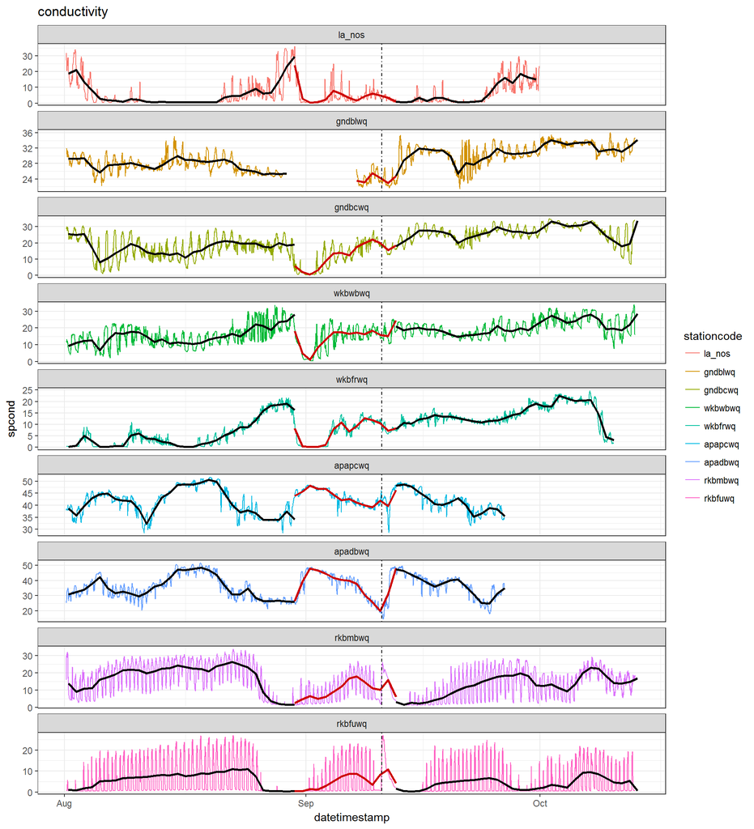

```r
landfall <- as.numeric(as.POSIXct("2017-09-10 12:00"))

ggplot() +
    geom_line(data=wq, aes(x=datetimestamp, y=spcond, col=stationcode)) +
    geom_line(data=wq_pre, aes(x=yymmdd, y=daily_mean), col="black", lwd=1) +
    geom_line(data=wq_storm, aes(x=yymmdd, y=daily_mean), col="red3", lwd=1) +
    geom_line(data=wq_post, aes(x=yymmdd, y=daily_mean), col="black", lwd=1) +
    geom_vline(data=wq, aes(xintercept = landfall), lty=4, col="black") +
    facet_wrap( ~stationcode, ncol=1, scales="free_y") +
    theme_bw() +
    ggtitle("conductivity")
```

### Do all this with depth because it might show more info

```r
wq_pre <- wq %>%
    filter(period == "pre") %>%
    mutate(month = month(datetimestamp),
           day = day(datetimestamp),
           year = year(datetimestamp),
           yymmdd = ymd_hm(paste0(year, "-", month, "-", day, " 12:00"))) %>%
    select(stationcode, yymmdd, depth) %>%
    group_by(stationcode, yymmdd) %>%
    summarize(daily_min = min(depth, na.rm=TRUE),
              daily_mean = mean(depth, na.rm=TRUE),
              daily_max = max(depth, na.rm=TRUE))

wq_storm <- wq %>%
    filter(period == "storm") %>%
    mutate(month = month(datetimestamp),
           day = day(datetimestamp),
           year = year(datetimestamp),
           yymmdd = ymd_hm(paste0(year, "-", month, "-", day, " 12:00"))) %>%
    select(stationcode, yymmdd, depth) %>%
    group_by(stationcode, yymmdd) %>%
    summarize(daily_min = min(depth, na.rm=TRUE),
              daily_mean = mean(depth, na.rm=TRUE),
              daily_max = max(depth, na.rm=TRUE))

wq_post <- wq %>%
    filter(period == "post") %>%
    mutate(month = month(datetimestamp),
           day = day(datetimestamp),
           year = year(datetimestamp),
           yymmdd = ymd_hm(paste0(year, "-", month, "-", day, " 12:00"))) %>%
    select(stationcode, yymmdd, depth) %>%
    group_by(stationcode, yymmdd) %>%
    summarize(daily_min = min(depth, na.rm=TRUE),
              daily_mean = mean(depth, na.rm=TRUE),
              daily_max = max(depth, na.rm=TRUE))
```

#### Plot it

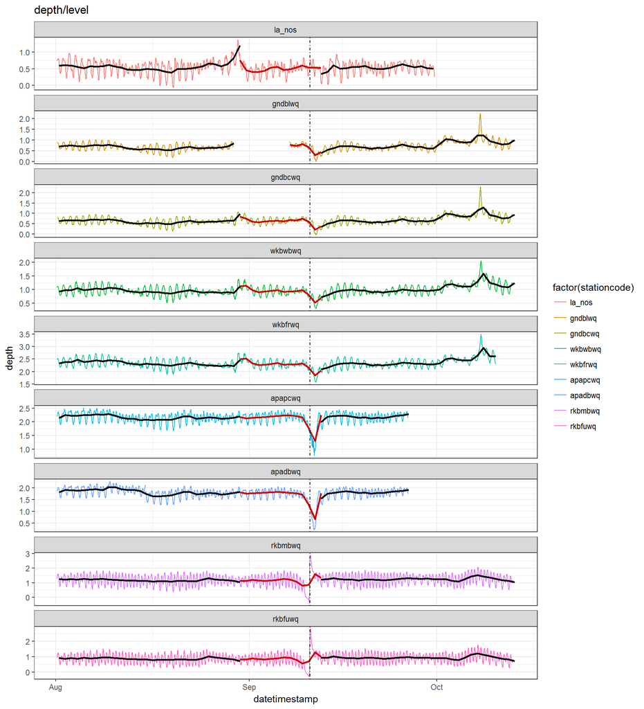

```r
ggplot() +
    geom_line(data=wq, aes(x=datetimestamp, y=depth, col=factor(stationcode))) +
    geom_line(data=wq_pre, aes(x=yymmdd, y=daily_mean), col="black", lwd=1) +
    geom_line(data=wq_storm, aes(x=yymmdd, y=daily_mean), col="red3", lwd=1) +
    geom_line(data=wq_post, aes(x=yymmdd, y=daily_mean), col="black", lwd=1) +
    geom_vline(data=wq, aes(xintercept = landfall), lty=4, col="black") +
    facet_wrap( ~stationcode, ncol=1, scales="free_y") +
    theme_bw() +
    ggtitle("depth/level")
```

### Find a value from the baseline period for comparison

Because there are sometimes other disturbances in what we would consider the baseline, I’ve chosen to use the median value from 15-minute data as the comparison point.

```r
wq_baselines <- wq %>%
    group_by(stationcode, period) %>%
    summarize(depth_median = round(median(depth, na.rm=TRUE), 3),
              depth_mean = round(mean(depth, na.rm=TRUE), 3),
              depth_min = min(depth, na.rm=TRUE),
              depth_max = max(depth, na.rm=TRUE))

kable(wq_baselines, caption = "summary statistics for each site by pre/during/post storm period")
```

summary statistics for each site by pre/during/post storm period

| stationcode | period | depth_median | depth_mean | depth_min | depth_max |
| --- | --- | --- | --- | --- | --- |
| la_nos | pre | 0.582 | 0.555 | -0.070 | 1.375 |
| la_nos | storm | 0.520 | 0.514 | 0.089 | 1.290 |
| la_nos | post | 0.560 | 0.534 | 0.023 | 0.945 |
| gndblwq | pre | 0.650 | 0.661 | 0.160 | 1.030 |
| gndblwq | storm | 0.700 | 0.635 | 0.000 | 0.930 |
| gndblwq | post | 0.750 | 0.771 | 0.230 | 2.250 |
| gndbcwq | pre | 0.600 | 0.609 | 0.120 | 1.050 |
| gndbcwq | storm | 0.630 | 0.622 | -0.050 | 1.090 |
| gndbcwq | post | 0.710 | 0.730 | 0.200 | 2.280 |
| wkbwbwq | pre | 0.940 | 0.947 | 0.510 | 1.340 |
| wkbwbwq | storm | 0.930 | 0.925 | 0.300 | 1.390 |
| wkbwbwq | post | 1.010 | 1.034 | 0.570 | 2.060 |
| wkbfrwq | pre | 2.310 | 2.328 | 1.880 | 2.740 |
| wkbfrwq | storm | 2.290 | 2.277 | 1.570 | 2.750 |
| wkbfrwq | post | 2.350 | 2.372 | 1.920 | 3.490 |
| apapcwq | pre | 2.190 | 2.164 | 1.680 | 2.510 |
| apapcwq | storm | 2.200 | 2.091 | 0.760 | 2.470 |
| apapcwq | post | 2.220 | 2.179 | 1.730 | 2.440 |
| apadbwq | pre | 1.840 | 1.824 | 1.260 | 2.270 |
| apadbwq | storm | 1.780 | 1.659 | 0.220 | 2.050 |
| apadbwq | post | 1.840 | 1.798 | 1.280 | 2.070 |
| rkbmbwq | pre | 1.190 | 1.180 | 0.360 | 1.830 |
| rkbmbwq | storm | 1.180 | 1.150 | -0.410 | 2.900 |
| rkbmbwq | post | 1.270 | 1.252 | 0.480 | 2.070 |
| rkbfuwq | pre | 0.870 | 0.870 | 0.240 | 1.490 |
| rkbfuwq | storm | 0.870 | 0.865 | -0.300 | 2.800 |
| rkbfuwq | post | 0.950 | 0.940 | 0.290 | 1.770 |

Mean and median really aren’t all that different, especially compared to those ranges. Interesting. But I have to pick something, so I choose median.

#### You know, I could make a box plot out of that.

Or a violin plot!!!

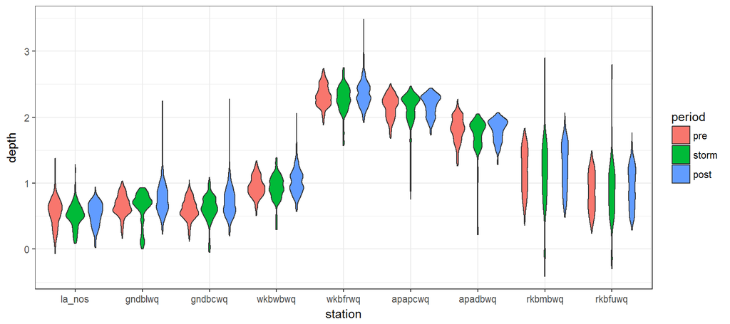

```r
ggplot(wq) +
    geom_violin(aes(x=stationcode, y=depth, fill=period)) +
    theme_bw() +
    xlab("station")
```

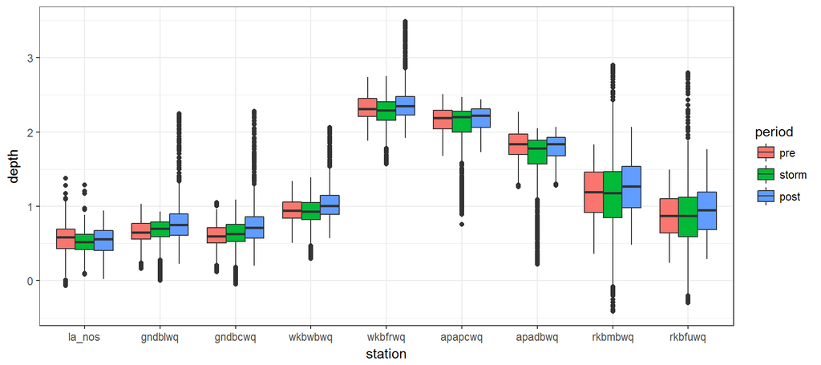

```r
ggplot(wq) +
    geom_boxplot(aes(x=stationcode, y=depth, fill=period)) +
    theme_bw() +
    xlab("station")
```

### Pick out most extreme values from storm and post-storm periods

Trim the data so it ends before Nate (cut it off at 10/01, a week before). Remove “pre” data.

```r
depth_max <- wq %>%
    filter(datetimestamp < "2017-10-02",
           period != "pre") %>%
    group_by(stationcode) %>%
    filter(datetimestamp == datetimestamp[which.max(depth)]) %>%
    select(stationcode, datetimestamp, depth, period)
kable(depth_max, caption = "maximum depths and time")
```

maximum depths and time

| stationcode | datetimestamp | depth | period |
| --- | --- | --- | --- |
| wkbfrwq | 2017-08-30 05:00:00 | 2.75 | storm |
| gndbcwq | 2017-08-30 05:30:00 | 1.09 | storm |
| wkbwbwq | 2017-08-30 07:30:00 | 1.39 | storm |
| apapcwq | 2017-09-06 14:30:00 | 2.47 | storm |
| rkbfuwq | 2017-09-10 19:00:00 | 2.80 | storm |
| rkbmbwq | 2017-09-10 19:30:00 | 2.90 | storm |
| apadbwq | 2017-09-16 11:00:00 | 2.07 | post |
| gndblwq | 2017-10-02 04:45:00 | 1.15 | post |
| la_nos | 2017-08-30 05:00:00 | 1.29 | storm |

```r
depth_min <- wq %>%
    filter(datetimestamp < "2017-10-02",
           period != "pre") %>%
    group_by(stationcode) %>%
    filter(datetimestamp == datetimestamp[which.min(depth)]) %>%
    select(stationcode, datetimestamp, depth, period)
kable(depth_min, caption = "minimum depths and time")
```

minimum depths and time

| stationcode | datetimestamp | depth | period |
| --- | --- | --- | --- |
| rkbfuwq | 2017-09-10 13:45:00 | -0.300 | storm |
| rkbmbwq | 2017-09-10 14:30:00 | -0.410 | storm |
| apadbwq | 2017-09-11 07:30:00 | 0.220 | storm |
| apapcwq | 2017-09-11 10:15:00 | 0.760 | storm |
| wkbfrwq | 2017-09-11 14:45:00 | 1.570 | storm |
| wkbwbwq | 2017-09-11 16:00:00 | 0.300 | storm |
| gndbcwq | 2017-09-11 16:00:00 | -0.050 | storm |
| gndblwq | 2017-09-11 16:30:00 | 0.000 | storm |
| la_nos | 2017-09-13 15:00:00 | 0.023 | post |